# Malnutrition in Africa - A Study

##### Sub-Saharan Africa has the highest proportion of undernourished children. Malnutrition in children is caused by a variety of factors such as the country's population, gross domestic product, education, and so on.

The aim of this study is to analyze the factos that contribute to malnutrition rate of the country

```python
import pandas as pd
import numpy as np
import matplotlib.pyplot as plt
import seaborn as sns
```

```python
import matplotlib
import cartopy
from cartopy.io import shapereader
import cartopy.crs as ccrs
import geopandas as gpd
import shapefile as shp
import matplotlib.cm as cm
```

#### Country Dataset

This file has two sheets

- consist of all countries around the world classified by regions and their country code
- countries in Africa and their income group

```python
#Countries dataset - All global countries with codes
df_contries = pd.read_excel(r'Countries/countriesData.xls', sheet_name='Metadata - Countries')
df_contries.head()
```

|  | Country Code | Region | IncomeGroup | SpecialNotes | TableName |
| --- | --- | --- | --- | --- | --- |
| 0 | ABW | Latin America & Caribbean | High income | NaN | Aruba |
| 1 | AFE | NaN | NaN | 26 countries, stretching from the Red Sea in t... | Africa Eastern and Southern |
| 2 | AFG | South Asia | Low income | Fiscal year end: March 20; reporting period fo... | Afghanistan |
| 3 | AFW | NaN | NaN | 22 countries, stretching from the westernmost ... | Africa Western and Central |
| 4 | AGO | Sub-Saharan Africa | Lower middle income | NaN | Angola |

```python
#Sub - Saharan African countries with codes
df_africa = pd.read_excel(r'Countries/countriesData.xls', sheet_name='Africa - Countries')
df_africa.drop(columns='#',inplace=True)
df_africa.head()
```

|  | Country | Population | Subregion |
| --- | --- | --- | --- |
| 0 | Nigeria | 206139589 | Western Africa |
| 1 | Ethiopia | 114963588 | Eastern Africa |
| 2 | Egypt | 102334404 | Northern Africa |
| 3 | Congo, Dem. Rep. | 89561403 | Middle Africa |
| 4 | Tanzania | 59734218 | Eastern Africa |

The countries dataset is merged with Sub - Saharan African dataset to get the income group details, population and sub regions

```python
df_africa = df_africa.merge(df_contries, how='left', left_on='Country', right_on = 'TableName')
df_africa.drop(columns=['Region','SpecialNotes','TableName'], inplace=True)
df_africa.dropna(inplace=True)
df_africa.head()
```

|  | Country | Population | Subregion | Country Code | IncomeGroup |
| --- | --- | --- | --- | --- | --- |
| 0 | Nigeria | 206139589 | Western Africa | NGA | Lower middle income |
| 1 | Ethiopia | 114963588 | Eastern Africa | ETH | Low income |
| 2 | Egypt | 102334404 | Northern Africa | EGY | Lower middle income |
| 3 | Congo, Dem. Rep. | 89561403 | Middle Africa | COD | Low income |
| 4 | Tanzania | 59734218 | Eastern Africa | TZA | Lower middle income |

```python
df_africa.info()
```

```
<class 'pandas.core.frame.DataFrame'>
Int64Index: 54 entries, 0 to 53
Data columns (total 5 columns):
 #   Column        Non-Null Count  Dtype
---  ------        --------------  -----
 0   Country       54 non-null     object
 1   Population    54 non-null     int64
 2   Subregion     54 non-null     object
 3   Country Code  54 non-null     object
 4   IncomeGroup   54 non-null     object
dtypes: int64(1), object(4)
memory usage: 2.5+ KB
```

#### Income Groups

- The Income groups are clasified based on the economy of the country.
- value_count() to get the exact number of countries falling under each income group

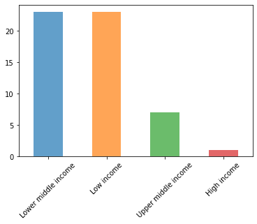

```python
plt.rcParams['figure.figsize'] = (6,4)
colors = ['#1f77b4', '#ff7f0e', '#2ca02c', '#d62728', '#9467bd']
df_africa['IncomeGroup'].value_counts().plot(kind='bar',
                                          #title='Income groups - Africa',
                                          color=colors, alpha=0.7)
plt.xticks(rotation=45)
plt.savefig('IncomeGroups_Africa.svg',bbox_inches='tight')
plt.show()
```

```python
df_africa['IncomeGroup'].value_counts()
```

```
Lower middle income    23
Low income             23
Upper middle income     7
High income             1
Name: IncomeGroup, dtype: int64
```

### Geographical distribution of Income groups

##### Using geopandas library to get the geographical location of Africa which was inturn mapped to income groups from df_africa dataframe; this is to obtain a income group distribution of countries

- It can be observed that the low income group are majorly distributed in the center of Africa
- There is only one country in high income group

```python
# get natural earth data from http://www.naturalearthdata.com/
# for country borders
res = '50m'
category = 'cultural'
name = 'admin_0_countries'
shpfilename = shapereader.natural_earth(res, category, name)

# read the shapefile using geopandas
geo_df = gpd.read_file(shpfilename)
```

```python
africa = geo_df[(geo_df['SOV_A3'].isin(df_africa['Country Code'])) |(geo_df['SOVEREIGNT'].isin(df_africa['Country']))]
africa = africa.merge(df_africa, how = 'left', left_on='SOV_A3', right_on = 'Country Code', )
```

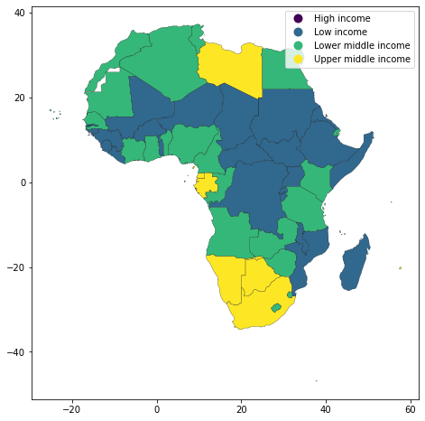

```python
africa.plot(column="IncomeGroup", edgecolor="black", lw=0.25, figsize=(8,8),cmap='viridis',legend=True, )
plt.savefig('IncomeGroupsDistribution_Africa.svg',bbox_inches='tight')
plt.show()
```

```python
africa[africa['IncomeGroup']=='Low income'][['SOVEREIGNT']]
```

|  | SOVEREIGNT |
| --- | --- |
| 2 | Uganda |
| 4 | Togo |
| 7 | South Sudan |
| 8 | Sudan |
| 10 | Somalia |
| 11 | Sierra Leone |
| 15 | Rwanda |
| 17 | Niger |
| 19 | Mozambique |
| 23 | Mali |
| 24 | Malawi |
| 25 | Madagascar |
| 27 | Liberia |
| 30 | Guinea-Bissau |
| 31 | Guinea |
| 33 | Gambia |
| 35 | Ethiopia |
| 36 | Eritrea |
| 41 | Democratic Republic of the Congo |
| 44 | Chad |
| 45 | Central African Republic |
| 48 | Burundi |
| 49 | Burkina Faso |

```python
africa[africa['IncomeGroup']=='High income'][['SOVEREIGNT']]
```

|  | SOVEREIGNT |
| --- | --- |
| 12 | Seychelles |

### Research Question #1

#### 1. Determine whether population has an impact on a country's economy and whether it influences malnutrition rate.

The below plot shows the distribution of population over African countries with dark being less populated and light colors representing densily populated regions

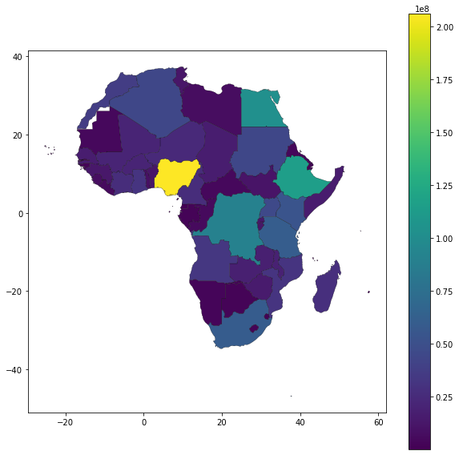

```python
africa.plot(column="Population",
            edgecolor="black", lw=0.25,
            figsize=(10,10),cmap='viridis',legend=True, )
plt.savefig('Population2019_Africa.svg',bbox_inches='tight')
plt.show()
```

### Africa Malnutrition - Stunting

The below file consist of stunting data of children between 0 - 59 months. Stunting is when a child's hight-for-age is lower than the WHO Child growth standards

```python
df_stunting = pd.read_excel(r'Global Malnutrition/JME_Country_Estimates_April_2021.xlsx', sheet_name='Stunting Proportion (Model)')
df_stunting.shape
```

```
(611, 27)
```

```python
df_stunting = df_stunting[df_stunting['ISO code'].isin(df_africa['Country Code'])]
df_stunting.head()
```

|  | ISO code | Country and areas | Note | Indicator | Measure | Estimate | 2000 | 2001 | 2002 | 2003 | ... | 2011 | 2012 | 2013 | 2014 | 2015 | 2016 | 2017 | 2018 | 2019 | 2020 |
| --- | --- | --- | --- | --- | --- | --- | --- | --- | --- | --- | --- | --- | --- | --- | --- | --- | --- | --- | --- | --- | --- |
| 6 | DZA | Algeria | NaN | Stunting | Proportion | Point Estimate | 22.1 | 21.3 | 20.5 | 19.7 | ... | 13.1 | 12.6 | 12.0 | 11.6 | 11.1 | 10.7 | 10.2 | 9.9 | 9.5 | 9.3 |
| 7 | DZA | Algeria | NaN | Stunting | Proportion | Lower Uncertainty Bound | 20.5 | 19.8 | 19.1 | 18.3 | ... | 12.0 | 11.5 | 11.0 | 10.5 | 10.1 | 9.6 | 9.1 | 8.7 | 8.3 | 8.0 |
| 8 | DZA | Algeria | NaN | Stunting | Proportion | Upper Uncertainty Bound | 23.7 | 22.9 | 22.0 | 21.1 | ... | 14.4 | 13.7 | 13.2 | 12.6 | 12.2 | 11.8 | 11.4 | 11.1 | 10.9 | 10.7 |
| 12 | AGO | Angola | NaN | Stunting | Proportion | Point Estimate | 47.8 | 45.1 | 42.4 | 39.9 | ... | 32.0 | 32.4 | 32.9 | 33.6 | 34.4 | 35.2 | 36.1 | 36.8 | 37.4 | 37.7 |
| 13 | AGO | Angola | NaN | Stunting | Proportion | Lower Uncertainty Bound | 44.3 | 41.6 | 39.0 | 36.6 | ... | 29.4 | 29.8 | 30.2 | 30.6 | 31.0 | 31.5 | 31.8 | 32.0 | 32.1 | 32.0 |

5 rows × 27 columns

```python
df_stunting2 = df_stunting.copy()
df_stunting2.shape
```

```
(162, 27)
```

```python
# Dropping unwanted columns
df_stunting.drop(columns=['Note'], inplace=True)
```

```python
df_stunting = pd.melt(df_stunting, id_vars=['ISO code', 'Country and areas',  'Indicator', 'Measure', 'Estimate'],var_name='Year', value_name='Affected-')
df_stunting.head()
```

|  | ISO code | Country and areas | Indicator | Measure | Estimate | Year | Affected- |
| --- | --- | --- | --- | --- | --- | --- | --- |
| 0 | DZA | Algeria | Stunting | Proportion | Point Estimate | 2000 | 22.1 |
| 1 | DZA | Algeria | Stunting | Proportion | Lower Uncertainty Bound | 2000 | 20.5 |
| 2 | DZA | Algeria | Stunting | Proportion | Upper Uncertainty Bound | 2000 | 23.7 |
| 3 | AGO | Angola | Stunting | Proportion | Point Estimate | 2000 | 47.8 |
| 4 | AGO | Angola | Stunting | Proportion | Lower Uncertainty Bound | 2000 | 44.3 |

```python
df_stunting['Estimate'].unique()
```

```
array(['Point Estimate', 'Lower Uncertainty Bound',
       'Upper Uncertainty Bound'], dtype=object)
```

```python
df_stunting = pd.pivot(df_stunting, index = ['ISO code', 'Country and areas',  'Indicator', 'Measure', 'Year'], columns = ['Estimate'])
```

##### Data transformation done to reshape the dataframe, it can be observed that Stunting data of every year is a seperate column and it would be easier to merge with trandformed data

```python
df_stunting = df_stunting.reset_index()
df_stunting.columns = [' '.join(col).strip() for col in df_stunting.columns]
df_stunting.head()
```

|  | ISO code | Country and areas | Indicator | Measure | Year | Affected- Lower Uncertainty Bound | Affected- Point Estimate | Affected- Upper Uncertainty Bound |
| --- | --- | --- | --- | --- | --- | --- | --- | --- |
| 0 | AGO | Angola | Stunting | Proportion | 2000 | 44.3 | 47.8 | 51.4 |
| 1 | AGO | Angola | Stunting | Proportion | 2001 | 41.6 | 45.1 | 48.6 |
| 2 | AGO | Angola | Stunting | Proportion | 2002 | 39.0 | 42.4 | 45.9 |
| 3 | AGO | Angola | Stunting | Proportion | 2003 | 36.6 | 39.9 | 43.4 |
| 4 | AGO | Angola | Stunting | Proportion | 2004 | 34.4 | 37.7 | 41.1 |

```python
df_stunting[['Year']] = df_stunting[['Year']].astype(int)
df_stunting[['Affected- Lower Uncertainty Bound', 'Affected- Point Estimate',
       'Affected- Upper Uncertainty Bound']] =  df_stunting[[
       'Affected- Lower Uncertainty Bound', 'Affected- Point Estimate',
       'Affected- Upper Uncertainty Bound']].astype(float)
```

##### ScatterPlot to determine if any outliers exist

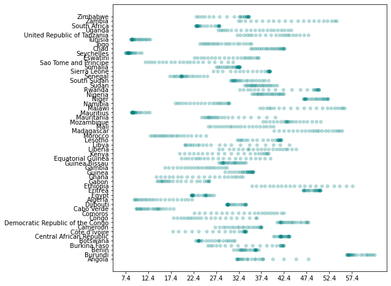

```python
plt.figure(figsize=(8, 8))
plt.scatter( df_stunting['Affected- Point Estimate'], df_stunting['Country and areas'],linewidth = 0, alpha=0.3, color='teal' )
plt.xticks(np.arange(df_stunting['Affected- Point Estimate'].min(), df_stunting['Affected- Point Estimate'].max(), 5))
plt.savefig('Scatterplot_stunting.svg',bbox_inches='tight')
plt.show()
```

Scatterplot to check for outliers, the values that seem like outliers are practical values and so no data is altered.